# Econ220 Final Project

D.Z.

05 January 2020

## Introduction

The reason I choose this data set is because this specific data set reflects various aspect of the sales of a large chain outdoor merchandise store. It includes data of various product lines, various locations of retails, and sales amount – all in periodic sequence between 2014 to 2017. With the numerous aspects to be compared of, wer are able to yield various comparisons with this data set, which will directly lead to a comprehensive analysis to the sales performance of this company overtime. With the results of analysis, we are even able to predict the future of the sales if there are clear trends.

## Import the Data Set

Here we import the required dataset to R.

```r
## Import the dataset
data_Sales <- (read_excel("OutDoorGearSales.xlsx", range = "A1:H75901"))
```

## Summarize the Data Set

```r
## Gives a summary of the structure of the dataframe "data_Sales"
str(data_Sales)
```

```
## Classes 'tbl_df', 'tbl' and 'data.frame':    75900 obs. of  8 variables:
##  $ Year           : num  2014 2014 2014 2014 2014 ...
##  $ ProductLine    : chr  "Camping Equipment" "Camping Equipment" "Camping Equipment" "Camping Equipment" ...
##  $ Product        : chr  "TrailChef Water Bag" "TrailChef Water Bag" "TrailChef Water Bag" "TrailChef Water Bag" ...
##  $ CustomerSegment: chr  "Segment 2" "Segment 2" "Segment 2" "Segment 2" ...
##  $ Location       : chr  "Store A" "Store A" "Store A" "Store A" ...
##  $ Month          : chr  "jan" "feb" "mar" "apr" ...
##  $ Sales          : num  71.4 74.6 72.2 78.3 96.3 ...
##  $ ProductType    : chr  "Cooking Gear" "Cooking Gear" "Cooking Gear" "Cooking Gear" ...
```

```r
## 75900 observations of 8 variables
```

## Analyze Sales by Location of Retials

To analyze the sales by location of retials, group the data set by retials and compare the sales made by each locations in periodic timeline.

```r
## This code create a new dataframe "lobation" that contains only useful columns from the original dataset, which are "Location", "Year", and "Sales"
location <- data_Sales %>%
  select(Location, Year, Sales) %>%
  group_by(Location, Year) %>%
  summarise(totalSales = sum(Sales))

## Use kable function to create a table of sales of certain year, grouped by locations
location %>%
  kable() %>%
  kable_styling()
```

| Location | Year | totalSales |
| --- | --- | --- |
| Flagship | 2014 | 1751956.8 |
| Flagship | 2015 | 2007019.4 |
| Flagship | 2016 | 2447560.4 |
| Flagship | 2017 | 2579396.6 |
| Online | 2014 | 411328.6 |
| Online | 2015 | 727065.0 |
| Online | 2016 | 1290514.3 |
| Online | 2017 | 1895872.6 |
| Store A | 2014 | 667059.3 |
| Store A | 2015 | 721023.2 |
| Store A | 2016 | 786653.7 |
| Store A | 2017 | 863966.7 |
| Store B | 2014 | 612289.6 |
| Store B | 2015 | 651036.8 |
| Store B | 2016 | 737249.0 |
| Store B | 2017 | 770290.4 |

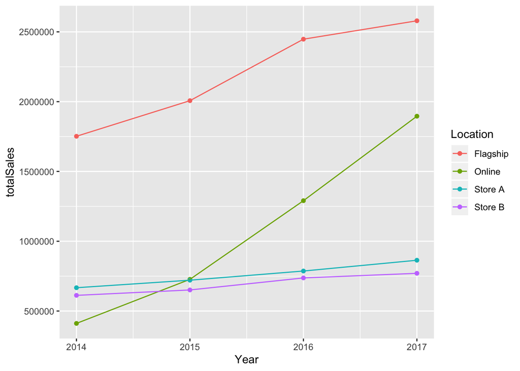

```r
## Create a Line chart to analyze the trend of sales in 2014 - 2017 of different segments
ggplot(data = location, mapping = aes(x = Year, y = totalSales, color = Location, group = interaction(Location))) + geom_point() + geom_line() + scale_x_continuous()
```

From the Graph we can clearly see that the Online sales segment has been growing the most rapidly during 2014 to 2017. Flagship sales segment achieved a decent increse in their sales as well, but not as significant as Online sales. The sales of Store A and Store B almost remained stagnant compared to that of Online and Flagship.

## Analyze Sales by Product Lines

To analyze the sales by production lines, group the data set by product lines and compare the sales made in each product lines in periodic timeline

```r
## This code create a new dataframe "pl" that contains only useful columns from the original dataset, which are "ProductLine", "Year", and "Sales"
pl <- data_Sales %>%
  select(ProductLine, Year, Sales) %>%
  group_by(ProductLine, Year) %>%
  summarise(totalSales = sum(Sales))

## Use kable function to create a table of sales of certain year, grouped by "ProductLine"
pl %>%
  kable() %>%
  kable_styling()
```

| ProductLine | Year | totalSales |
| --- | --- | --- |
| Camping Equipment | 2014 | 1217016.13 |
| Camping Equipment | 2015 | 1428004.98 |
| Camping Equipment | 2016 | 1530980.97 |
| Camping Equipment | 2017 | 1602228.99 |
| Golf Equipment | 2014 | 554194.00 |
| Golf Equipment | 2015 | 569053.67 |
| Golf Equipment | 2016 | 809098.39 |
| Golf Equipment | 2017 | 975946.08 |
| Mountaineering Equipment | 2015 | 368708.78 |
| Mountaineering Equipment | 2016 | 570206.63 |
| Mountaineering Equipment | 2017 | 810357.68 |
| Outdoor Protection | 2014 | 133421.58 |
| Outdoor Protection | 2015 | 85894.33 |
| Outdoor Protection | 2016 | 37321.54 |
| Outdoor Protection | 2017 | 25655.74 |
| Personal Accessories | 2014 | 1538002.61 |
| Personal Accessories | 2015 | 1654482.63 |
| Personal Accessories | 2016 | 2314369.77 |
| Personal Accessories | 2017 | 2695337.78 |

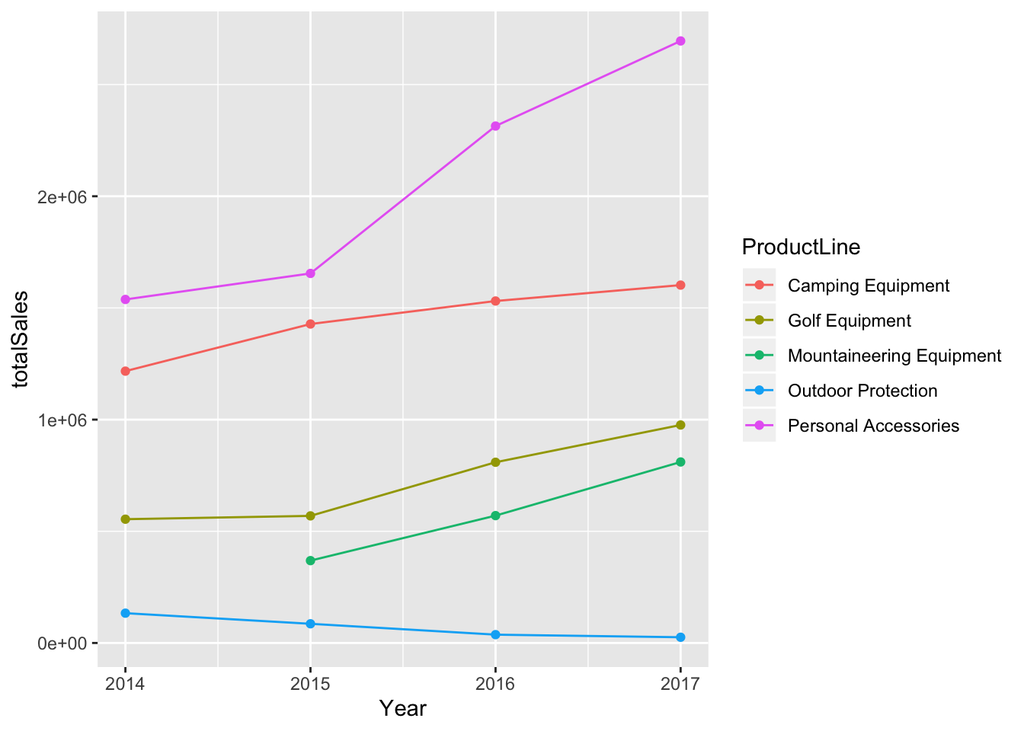

```r
## Create a Line chart to analyze the trend of sales in 2014 - 2017 of different "ProductLine"
ggplot(data = pl, mapping = aes(x = Year, y = totalSales, color = ProductLine, group = interaction(ProductLine))) + geom_point() + geom_line() + scale_x_continuous()
```

The increment of sales of Personal accessaries achieved a significant boost started from 2015, and so does Golf Equipment, eventhought the increment was not as significant as that of Personal Accessories. The sales of camping equipment and that of Mountaineering Equipment, which was not introduced until 2015, also elevated throughout the time. The only downfall in sales is the Outdoor Protection, which kept decreasing from 2014 to 2017.

## Analyze the Overall Performance of Sales

To analyze the overall sales performance, group the data set by year and compare the sales made in each year and analyze the trend.

```r
## This code create a new dataframe "year" that contains only useful columns from the original dataset, which are "Year", and "Sales"
year<- data_Sales %>%
  select(Year, Sales) %>%
  group_by(Year) %>%
  summarise(totalSales = sum(Sales))

## Use kable function to create a table of total sales of certain year
year %>%
  kable() %>%
  kable_styling()
```

| Year | totalSales |
| --- | --- |
| 2014 | 3442634 |
| 2015 | 4106144 |
| 2016 | 5261977 |
| 2017 | 6109526 |

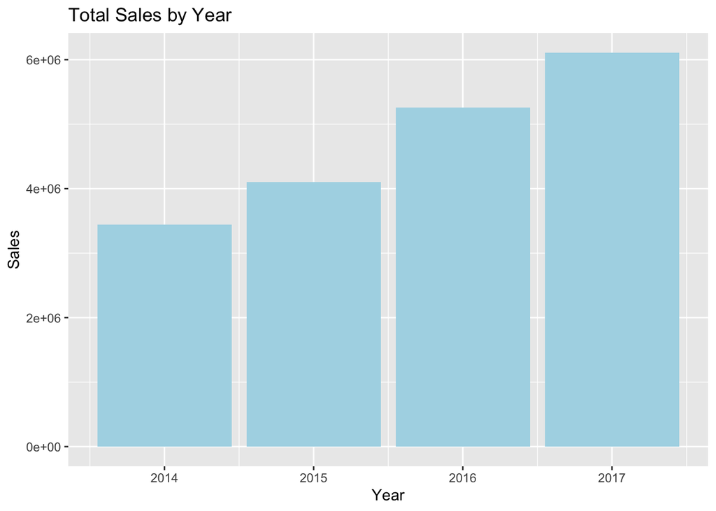

```r
## Create a box chart to analyze the amount of total sales in 2014 - 2017
ggplot(data = year, aes(x = Year, y = totalSales, label = totalSales)) +
  geom_col(fill = "light blue") +
  ylab("Sales") + xlab("Year") +
  ggtitle("Total Sales by Year")
```

## Source of Data Set

This data set was offered by a friend of mine. The origin of this data set was offered as an Interview preparation material of a consulting firm.